# 596077

```python
import pandas as pd
import numpy as np
import matplotlib.pyplot as plt
```

```python
# Download the data as pandas dataframe object
data = pd.read_csv("corrtestdata.csv")
data.head()
```

|  | id | day | weight | gender | liverind | heartind | appind | femstate | gonfatind | batind | sulcer | kmethod | tailind | blength | place | year | ADWBind | gonind | BMI |
| --- | --- | --- | --- | --- | --- | --- | --- | --- | --- | --- | --- | --- | --- | --- | --- | --- | --- | --- | --- |
| 0 | rat1 | 67 | 22.0 | 1 | 0.036364 | 0.005091 | 0.013636 | 4 | 0.000000 | 0.001864 | 1 | 2 | 0.714286 | 10.5 | 1 | 5 | 0.454545 | 0.000000 | 0.199546 |
| 1 | rat2 | 251 | 182.0 | 1 | 0.010440 | 0.004396 | 0.008791 | 4 | 0.023077 | 0.000742 | 3 | 2 | 0.666667 | 19.5 | 3 | 3 | 0.302198 | 1.648659 | 0.478632 |
| 2 | rat3 | 230 | 37.5 | 1 | 0.051200 | 0.006133 | 0.020800 | 4 | 0.000000 | 0.001467 | 2 | 1 | 0.904762 | 10.5 | 2 | 8 | 0.653333 | 0.000000 | 0.340136 |
| 3 | rat4 | 261 | 45.0 | 2 | 0.047333 | 0.005556 | 0.105111 | -1 | 0.293333 | 0.002178 | 1 | 1 | 0.869565 | 11.5 | 4 | 2 | 0.260000 | 2.653242 | 0.340265 |
| 4 | rat5 | 262 | 43.0 | 1 | 0.052558 | 0.005349 | 0.021628 | 4 | 0.000000 | 0.001884 | 1 | 1 | 0.720000 | 12.5 | 2 | 8 | 0.500000 | 0.000000 | 0.275200 |

```python
data.describe()
```

|  | day | weight | gender | liverind | heartind | appind | femstate | gonfatind | batind | sulcer | kmethod | tailind | blength | place | year | ADWBind | gonind | BMI |
| --- | --- | --- | --- | --- | --- | --- | --- | --- | --- | --- | --- | --- | --- | --- | --- | --- | --- | --- |
| count | 563.000000 | 563.000000 | 563.000000 | 563.000000 | 563.000000 | 563.000000 | 563.000000 | 563.000000 | 563.000000 | 563.000000 | 563.000000 | 563.000000 | 563.000000 | 563.000000 | 563.000000 | 563.000000 | 563.000000 | 563.000000 |
| mean | 185.609236 | 266.009769 | 1.373002 | 0.053103 | 0.011241 | 0.014330 | 1.415631 | 0.009233 | 0.001392 | 1.436945 | 1.547069 | 0.783158 | 20.462877 | 2.490231 | 6.662522 | 0.386439 | 0.953519 | 0.603400 |
| std | 94.541938 | 99.563358 | 0.484033 | 0.017590 | 0.167074 | 0.006936 | 2.095896 | 0.017207 | 0.000620 | 0.852578 | 1.207555 | 0.060422 | 2.897211 | 1.571938 | 2.985695 | 0.131427 | 0.769399 | 0.130781 |
| min | 12.000000 | 22.000000 | 1.000000 | 0.010440 | 0.002215 | 0.002949 | -1.000000 | 0.000000 | 0.000031 | 1.000000 | 1.000000 | 0.500000 | 10.500000 | 1.000000 | 2.000000 | 0.052299 | 0.000000 | 0.130874 |
| 25% | 127.000000 | 202.500000 | 1.000000 | 0.042737 | 0.003615 | 0.010406 | -1.000000 | 0.001846 | 0.000929 | 1.000000 | 1.000000 | 0.750000 | 19.500000 | 2.000000 | 5.000000 | 0.292102 | 0.262364 | 0.514815 |
| 50% | 177.000000 | 275.000000 | 1.000000 | 0.051402 | 0.004106 | 0.013456 | 1.000000 | 0.005686 | 0.001287 | 1.000000 | 1.000000 | 0.778846 | 21.000000 | 2.000000 | 7.000000 | 0.379808 | 0.970779 | 0.607743 |
| 75% | 250.500000 | 339.000000 | 2.000000 | 0.061439 | 0.004637 | 0.016789 | 4.000000 | 0.010382 | 0.001723 | 2.000000 | 2.000000 | 0.824316 | 22.500000 | 2.000000 | 8.000000 | 0.466617 | 1.410987 | 0.694640 |
| max | 400.000000 | 500.000000 | 2.000000 | 0.309273 | 3.968379 | 0.105111 | 4.000000 | 0.293333 | 0.004866 | 5.000000 | 6.000000 | 0.986667 | 26.500000 | 9.000000 | 15.000000 | 0.974359 | 3.945264 | 1.005949 |

## a)

Calculate all pairwise correlations between features, excluding only the rat id. Report strongest correlations involving i) categorical features, ii) temporal features day and year, ii) other numerical features.

```python
pairwise_correlations = data.corr(method='pearson').round(decimals=2)
pairwise_correlations
```

|  | day | weight | gender | liverind | heartind | appind | femstate | gonfatind | batind | sulcer | kmethod | tailind | blength | place | year | ADWBind | gonind | BMI |
| --- | --- | --- | --- | --- | --- | --- | --- | --- | --- | --- | --- | --- | --- | --- | --- | --- | --- | --- |
| day | 1.00 | 0.12 | -0.25 | -0.12 | -0.01 | 0.22 | 0.26 | 0.39 | -0.14 | -0.24 | 0.45 | 0.28 | 0.00 | 0.70 | 0.40 | -0.20 | 0.44 | 0.20 |
| weight | 0.12 | 1.00 | -0.09 | -0.24 | -0.01 | -0.19 | -0.01 | 0.15 | -0.20 | -0.11 | 0.19 | -0.22 | 0.88 | 0.24 | 0.24 | -0.41 | 0.53 | 0.88 |
| gender | -0.25 | -0.09 | 1.00 | -0.21 | 0.06 | -0.16 | -0.89 | -0.06 | -0.00 | 0.05 | -0.15 | -0.07 | -0.10 | -0.25 | -0.11 | -0.24 | -0.04 | -0.11 |
| liverind | -0.12 | -0.24 | -0.21 | 1.00 | -0.04 | 0.30 | 0.16 | -0.26 | 0.09 | -0.04 | -0.32 | 0.09 | -0.19 | -0.31 | -0.07 | 0.33 | -0.40 | -0.24 |
| heartind | -0.01 | -0.01 | 0.06 | -0.04 | 1.00 | -0.06 | -0.05 | 0.01 | -0.04 | 0.13 | 0.01 | -0.04 | 0.02 | 0.01 | -0.05 | -0.06 | 0.02 | -0.03 |
| appind | 0.22 | -0.19 | -0.16 | 0.30 | -0.06 | 1.00 | 0.21 | 0.43 | 0.15 | -0.11 | 0.12 | 0.17 | -0.22 | 0.22 | 0.17 | -0.01 | -0.01 | -0.15 |
| femstate | 0.26 | -0.01 | -0.89 | 0.16 | -0.05 | 0.21 | 1.00 | 0.10 | 0.09 | -0.06 | 0.26 | 0.12 | -0.03 | 0.30 | 0.23 | 0.19 | 0.04 | 0.04 |
| gonfatind | 0.39 | 0.15 | -0.06 | -0.26 | 0.01 | 0.43 | 0.10 | 1.00 | 0.15 | -0.11 | 0.49 | 0.08 | 0.06 | 0.57 | 0.27 | -0.32 | 0.68 | 0.19 |
| batind | -0.14 | -0.20 | -0.00 | 0.09 | -0.04 | 0.15 | 0.09 | 0.15 | 1.00 | 0.04 | 0.20 | -0.04 | -0.21 | 0.14 | 0.01 | 0.03 | 0.07 | -0.20 |
| sulcer | -0.24 | -0.11 | 0.05 | -0.04 | 0.13 | -0.11 | -0.06 | -0.11 | 0.04 | 1.00 | -0.00 | -0.21 | -0.02 | -0.19 | -0.21 | 0.28 | -0.18 | -0.17 |
| kmethod | 0.45 | 0.19 | -0.15 | -0.32 | 0.01 | 0.12 | 0.26 | 0.49 | 0.20 | -0.00 | 1.00 | 0.06 | 0.10 | 0.77 | 0.54 | -0.25 | 0.52 | 0.24 |
| tailind | 0.28 | -0.22 | -0.07 | 0.09 | -0.04 | 0.17 | 0.12 | 0.08 | -0.04 | -0.21 | 0.06 | 1.00 | -0.42 | 0.18 | 0.30 | 0.05 | -0.03 | 0.08 |
| blength | 0.00 | 0.88 | -0.10 | -0.19 | 0.02 | -0.22 | -0.03 | 0.06 | -0.21 | -0.02 | 0.10 | -0.42 | 1.00 | 0.14 | -0.01 | -0.37 | 0.44 | 0.60 |
| place | 0.70 | 0.24 | -0.25 | -0.31 | 0.01 | 0.22 | 0.30 | 0.57 | 0.14 | -0.19 | 0.77 | 0.18 | 0.14 | 1.00 | 0.46 | -0.38 | 0.66 | 0.28 |
| year | 0.40 | 0.24 | -0.11 | -0.07 | -0.05 | 0.17 | 0.23 | 0.27 | 0.01 | -0.21 | 0.54 | 0.30 | -0.01 | 0.46 | 1.00 | -0.16 | 0.34 | 0.43 |
| ADWBind | -0.20 | -0.41 | -0.24 | 0.33 | -0.06 | -0.01 | 0.19 | -0.32 | 0.03 | 0.28 | -0.25 | 0.05 | -0.37 | -0.38 | -0.16 | 1.00 | -0.53 | -0.38 |
| gonind | 0.44 | 0.53 | -0.04 | -0.40 | 0.02 | -0.01 | 0.04 | 0.68 | 0.07 | -0.18 | 0.52 | -0.03 | 0.44 | 0.66 | 0.34 | -0.53 | 1.00 | 0.50 |
| BMI | 0.20 | 0.88 | -0.11 | -0.24 | -0.03 | -0.15 | 0.04 | 0.19 | -0.20 | -0.17 | 0.24 | 0.08 | 0.60 | 0.28 | 0.43 | -0.38 | 0.50 | 1.00 |

### i)

Categorical variables are the following:

- gender binary (nominal)
- femstate nominal
- sulcer ordinal
- kmethod nominal
- place nominal

```python
pairwise_correlations[['gender', 'femstate', 'sulcer', 'kmethod', 'place']].where(lambda x: (np.abs(x) >= 0.4))
```

|  | gender | femstate | sulcer | kmethod | place |
| --- | --- | --- | --- | --- | --- |
| day | NaN | NaN | NaN | 0.45 | 0.70 |
| weight | NaN | NaN | NaN | NaN | NaN |
| gender | 1.00 | -0.89 | NaN | NaN | NaN |
| liverind | NaN | NaN | NaN | NaN | NaN |
| heartind | NaN | NaN | NaN | NaN | NaN |
| appind | NaN | NaN | NaN | NaN | NaN |
| femstate | -0.89 | 1.00 | NaN | NaN | NaN |
| gonfatind | NaN | NaN | NaN | 0.49 | 0.57 |
| batind | NaN | NaN | NaN | NaN | NaN |
| sulcer | NaN | NaN | 1.0 | NaN | NaN |
| kmethod | NaN | NaN | NaN | 1.00 | 0.77 |
| tailind | NaN | NaN | NaN | NaN | NaN |
| blength | NaN | NaN | NaN | NaN | NaN |
| place | NaN | NaN | NaN | 0.77 | 1.00 |
| year | NaN | NaN | NaN | 0.54 | 0.46 |
| ADWBind | NaN | NaN | NaN | NaN | NaN |
| gonind | NaN | NaN | NaN | 0.52 | 0.66 |
| BMI | NaN | NaN | NaN | NaN | NaN |

The strongest pairwise correlations involving categorical features are between

- gender and femstate (-0.89)
- killing method and place/group (0.77)
- place/group and date of death (0.70)

### ii)

```python
pairwise_correlations[['day', 'year']].where(lambda x: (np.abs(x) >= 0.4))
```

|  | day | year |
| --- | --- | --- |
| day | 1.00 | 0.40 |
| weight | NaN | NaN |
| gender | NaN | NaN |
| liverind | NaN | NaN |
| heartind | NaN | NaN |
| appind | NaN | NaN |
| femstate | NaN | NaN |
| gonfatind | NaN | NaN |
| batind | NaN | NaN |
| sulcer | NaN | NaN |
| kmethod | 0.45 | 0.54 |
| tailind | NaN | NaN |
| blength | NaN | NaN |
| place | 0.70 | 0.46 |
| year | 0.40 | 1.00 |
| ADWBind | NaN | NaN |
| gonind | 0.44 | NaN |
| BMI | NaN | 0.43 |

The strongest pairwise correlations involving temporal features day and year are between

- date of death and place/group (0.70)
- year of death and killing method (0.54)

### iii)

```python
pairwise_correlations[['weight', 'liverind', 'heartind', 'appind', 'gonfatind', 'batind',
                       'tailind', 'blength', 'ADWBind', 'gonind', 'BMI']].where(lambda x: (np.abs(x) >= 0.4))
```

|  | weight | liverind | heartind | appind | gonfatind | batind | tailind | blength | ADWBind | gonind | BMI |
| --- | --- | --- | --- | --- | --- | --- | --- | --- | --- | --- | --- |
| day | NaN | NaN | NaN | NaN | NaN | NaN | NaN | NaN | NaN | 0.44 | NaN |
| weight | 1.00 | NaN | NaN | NaN | NaN | NaN | NaN | 0.88 | -0.41 | 0.53 | 0.88 |
| gender | NaN | NaN | NaN | NaN | NaN | NaN | NaN | NaN | NaN | NaN | NaN |
| liverind | NaN | 1.0 | NaN | NaN | NaN | NaN | NaN | NaN | NaN | -0.40 | NaN |
| heartind | NaN | NaN | 1.0 | NaN | NaN | NaN | NaN | NaN | NaN | NaN | NaN |
| appind | NaN | NaN | NaN | 1.00 | 0.43 | NaN | NaN | NaN | NaN | NaN | NaN |
| femstate | NaN | NaN | NaN | NaN | NaN | NaN | NaN | NaN | NaN | NaN | NaN |
| gonfatind | NaN | NaN | NaN | 0.43 | 1.00 | NaN | NaN | NaN | NaN | 0.68 | NaN |
| batind | NaN | NaN | NaN | NaN | NaN | 1.0 | NaN | NaN | NaN | NaN | NaN |
| sulcer | NaN | NaN | NaN | NaN | NaN | NaN | NaN | NaN | NaN | NaN | NaN |
| kmethod | NaN | NaN | NaN | NaN | 0.49 | NaN | NaN | NaN | NaN | 0.52 | NaN |
| tailind | NaN | NaN | NaN | NaN | NaN | NaN | 1.00 | -0.42 | NaN | NaN | NaN |
| blength | 0.88 | NaN | NaN | NaN | NaN | NaN | -0.42 | 1.00 | NaN | 0.44 | 0.60 |
| place | NaN | NaN | NaN | NaN | 0.57 | NaN | NaN | NaN | NaN | 0.66 | NaN |
| year | NaN | NaN | NaN | NaN | NaN | NaN | NaN | NaN | NaN | NaN | 0.43 |
| ADWBind | -0.41 | NaN | NaN | NaN | NaN | NaN | NaN | NaN | 1.00 | -0.53 | NaN |
| gonind | 0.53 | -0.4 | NaN | NaN | 0.68 | NaN | NaN | 0.44 | -0.53 | 1.00 | 0.50 |
| BMI | 0.88 | NaN | NaN | NaN | NaN | NaN | NaN | 0.60 | NaN | 0.50 | 1.00 |

The strongest pairwise correlations involving other numerical features than day and year are between

## b)

```python
# Remove outliers
dataB = data.set_index('id').drop(['rat2', 'rat53', 'rat120','rat434'])
```

```python
# Calculate pairwise correlations
pairwise_correlationsB = dataB.corr(method='pearson').round(decimals=2)
```

```python
# Compare the correlations involving heartind before and after removing the outliers
change = pd.concat([pairwise_correlations['heartind'].rename('heartind, before'),
                    pairwise_correlationsB['heartind'].rename('heartind, after')],
                   axis=1)
change
```

|  | heartind, before | heartind, after |
| --- | --- | --- |
| day | -0.01 | -0.45 |
| weight | -0.01 | -0.49 |
| gender | 0.06 | 0.26 |
| liverind | -0.04 | 0.23 |
| heartind | 1.00 | 1.00 |
| appind | -0.06 | -0.03 |
| femstate | -0.05 | -0.23 |
| gonfatind | 0.01 | -0.30 |
| batind | -0.04 | 0.17 |
| sulcer | 0.13 | 0.20 |
| kmethod | 0.01 | -0.35 |
| tailind | -0.04 | -0.12 |
| blength | 0.02 | -0.42 |
| place | 0.01 | -0.47 |
| year | -0.05 | -0.41 |
| ADWBind | -0.06 | 0.31 |
| gonind | 0.02 | -0.55 |
| BMI | -0.03 | -0.55 |

The correlation between heartind and

- day
- weight
- blength
- place
- year
- gonind
- BMI

changed a lot from weak to strong.

There were some other big changes too but they are not mentioned because the absolute after values were not greater than 0.4. All the correlations involving heartind had weak correlation before.

```python
# Compare the correlations involving liverind before and after removing the outliers
change = pd.concat([pairwise_correlations['liverind'].rename('liverind, before'),
                    pairwise_correlationsB['liverind'].rename('liverind, after')],
                   axis=1)
change
```

|  | liverind, before | liverind, after |
| --- | --- | --- |
| day | -0.12 | -0.18 |
| weight | -0.24 | -0.24 |
| gender | -0.21 | -0.25 |
| liverind | 1.00 | 1.00 |
| heartind | -0.04 | 0.23 |
| appind | 0.30 | 0.09 |
| femstate | 0.16 | 0.16 |
| gonfatind | -0.26 | -0.32 |
| batind | 0.09 | 0.01 |
| sulcer | -0.04 | -0.02 |
| kmethod | -0.32 | -0.40 |
| tailind | 0.09 | 0.08 |
| blength | -0.19 | -0.24 |
| place | -0.31 | -0.38 |
| year | -0.07 | -0.12 |
| ADWBind | 0.33 | 0.46 |
| gonind | -0.40 | -0.48 |
| BMI | -0.24 | -0.19 |

The correlation between liverind and

- kmethod

changed a little from weak to strong.

The correlation between liverind and

- ADWBind

changed a lot from weak to strong.

There were some other big changes too but they are not mentioned because the absolute after values were not greater or equal than 0.4. Most of the correlation changes were less than 0.1 though.

```python
# Calculate the mean absolute difference after removing the outliers
ma_heartind = np.mean(np.abs(pairwise_correlations['heartind'] - pairwise_correlationsB['heartind']), axis=0)
ma_liverind = np.mean(np.abs(pairwise_correlations['liverind'] - pairwise_correlationsB['liverind']), axis=0)
ma_heartind, ma_liverind
```

```
(0.2983333333333333, 0.07)
```

The mean absolute differences tells us that the correlations involving heartind changed by 0.30 on average and the correlations involving liverind changed by 0.07 on average.

By removing the outliers we decreased the variability of the data and this increased the statistical power. The pearson correlation coefficient measures the strength and direction of a linear relationship between two variables. The removed outliers shifted the data mean too much and by removing those the mean now better described the sample. This is why the changes were quite big on some of the correlations. (See the figure below as an additional illustration of this.)

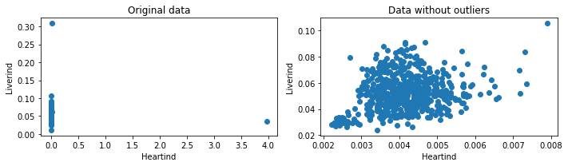

```python
fig, ax = plt.subplots(1, 2, figsize=(10,3));

ax[0].scatter(data.heartind, data.liverind)
ax[0].set_title('Original data')
ax[0].set_xlabel('Heartind')
ax[0].set_ylabel('Liverind')

ax[1].scatter(dataB.heartind, dataB.liverind)
ax[1].set_title('Data without outliers')
ax[1].set_xlabel('Heartind')
ax[1].set_ylabel('Liverind')

fig.tight_layout()
```

## c)

#### Continue with the data from b), where the listed outliers are removed. Change the special codes for the freezer rats: day=0 and year=-1

```python
dataC = dataB.copy()
dataC['day'].replace({400: 0}, inplace=True)
dataC['year'].replace({15: -1}, inplace=True)
# print the original correlations
dataC.head()
```

| id | day | weight | gender | liverind | heartind | appind | femstate | gonfatind | batind | sulcer | kmethod | tailind | blength | place | year | ADWBind | gonind | BMI |
| --- | --- | --- | --- | --- | --- | --- | --- | --- | --- | --- | --- | --- | --- | --- | --- | --- | --- | --- |
| rat1 | 67 | 22.0 | 1 | 0.036364 | 0.005091 | 0.013636 | 4 | 0.000000 | 0.001864 | 1 | 2 | 0.714286 | 10.5 | 1 | 5 | 0.454545 | 0.000000 | 0.199546 |
| rat3 | 230 | 37.5 | 1 | 0.051200 | 0.006133 | 0.020800 | 4 | 0.000000 | 0.001467 | 2 | 1 | 0.904762 | 10.5 | 2 | 8 | 0.653333 | 0.000000 | 0.340136 |
| rat4 | 261 | 45.0 | 2 | 0.047333 | 0.005556 | 0.105111 | -1 | 0.293333 | 0.002178 | 1 | 1 | 0.869565 | 11.5 | 4 | 2 | 0.260000 | 2.653242 | 0.340265 |
| rat5 | 262 | 43.0 | 1 | 0.052558 | 0.005349 | 0.021628 | 4 | 0.000000 | 0.001884 | 1 | 1 | 0.720000 | 12.5 | 2 | 8 | 0.500000 | 0.000000 | 0.275200 |
| rat6 | 169 | 40.0 | 1 | 0.057250 | 0.006500 | 0.014000 | 4 | 0.000000 | 0.002925 | 2 | 1 | 0.826087 | 11.5 | 2 | 7 | 0.575000 | 0.000000 | 0.302457 |

#### How did the correlations involving either day or year change?

```python
pairwise_correlationsC = dataC.corr(method='pearson').round(decimals=2)
change = pairwise_correlationsB[['day', 'year']] - pairwise_correlationsC[['day', 'year']]
change
```

|  | day | year |
| --- | --- | --- |
| day | 0.00 | 0.11 |
| weight | 0.26 | 0.33 |
| gender | -0.19 | -0.26 |
| liverind | -0.39 | -0.51 |
| heartind | -0.47 | -0.60 |
| appind | 0.22 | 0.29 |
| femstate | 0.32 | 0.42 |
| gonfatind | 0.55 | 0.72 |
| batind | 0.23 | 0.28 |
| sulcer | -0.11 | -0.15 |
| kmethod | 0.98 | 1.27 |
| tailind | 0.16 | 0.20 |
| blength | 0.11 | 0.13 |
| place | 0.90 | 1.19 |
| year | 0.11 | 0.00 |
| ADWBind | -0.31 | -0.41 |
| gonind | 0.61 | 0.81 |
| BMI | 0.36 | 0.43 |

```python
np.abs(change).mean(axis=0)
```

```
day     0.348889
year    0.450556
dtype: float64
```

#### What happens if you remove all freezer rats?

```python
dataC_first_part = dataC.copy()
pairwise_correlationsC_first_part = pairwise_correlationsC.copy()
dataC['day'].replace({0: np.nan}, inplace=True)
dataC['year'].replace({-1: np.nan}, inplace=True)
dataC = dataC.dropna(axis=0, how='any')
dataC
```

| id | day | weight | gender | liverind | heartind | appind | femstate | gonfatind | batind | sulcer | kmethod | tailind | blength | place | year | ADWBind | gonind | BMI |
| --- | --- | --- | --- | --- | --- | --- | --- | --- | --- | --- | --- | --- | --- | --- | --- | --- | --- | --- |
| rat1 | 67.0 | 22.0 | 1 | 0.036364 | 0.005091 | 0.013636 | 4 | 0.000000 | 0.001864 | 1 | 2 | 0.714286 | 10.5 | 1 | 5.0 | 0.454545 | 0.000000 | 0.199546 |
| rat3 | 230.0 | 37.5 | 1 | 0.051200 | 0.006133 | 0.020800 | 4 | 0.000000 | 0.001467 | 2 | 1 | 0.904762 | 10.5 | 2 | 8.0 | 0.653333 | 0.000000 | 0.340136 |
| rat4 | 261.0 | 45.0 | 2 | 0.047333 | 0.005556 | 0.105111 | -1 | 0.293333 | 0.002178 | 1 | 1 | 0.869565 | 11.5 | 4 | 2.0 | 0.260000 | 2.653242 | 0.340265 |
| rat5 | 262.0 | 43.0 | 1 | 0.052558 | 0.005349 | 0.021628 | 4 | 0.000000 | 0.001884 | 1 | 1 | 0.720000 | 12.5 | 2 | 8.0 | 0.500000 | 0.000000 | 0.275200 |
| rat6 | 169.0 | 40.0 | 1 | 0.057250 | 0.006500 | 0.014000 | 4 | 0.000000 | 0.002925 | 2 | 1 | 0.826087 | 11.5 | 2 | 7.0 | 0.575000 | 0.000000 | 0.302457 |
| ... | ... | ... | ... | ... | ... | ... | ... | ... | ... | ... | ... | ... | ... | ... | ... | ... | ... | ... |
| rat574 | 127.0 | 442.0 | 1 | 0.067738 | 0.003507 | 0.013552 | 3 | 0.010656 | 0.002602 | 1 | 1 | 0.808163 | 24.5 | 2 | 7.0 | 0.372172 | 1.742219 | 0.736360 |
| rat575 | 269.0 | 381.8 | 1 | 0.078575 | 0.003667 | 0.014667 | 4 | 0.004976 | 0.001035 | 1 | 1 | 0.777273 | 22.0 | 2 | 6.0 | 0.381090 | 1.064711 | 0.788843 |
| rat576 | 169.0 | 416.0 | 1 | 0.079303 | 0.003918 | 0.014760 | 1 | 0.004087 | 0.001337 | 1 | 1 | 0.760870 | 23.0 | 2 | 7.0 | 0.469952 | 0.993252 | 0.786389 |
| rat577 | 244.0 | 476.0 | 1 | 0.080693 | 0.004286 | 0.008803 | 2 | 0.007437 | 0.001592 | 1 | 1 | 0.714286 | 24.5 | 2 | 8.0 | 0.380252 | 1.512927 | 0.793003 |
| rat578 | 230.0 | 459.0 | 1 | 0.085251 | 0.003682 | 0.016144 | 2 | 0.001089 | 0.001218 | 1 | 1 | 0.816327 | 24.5 | 2 | 8.0 | 0.517429 | 0.405465 | 0.764681 |

525 rows × 18 columns

```python
pairwise_correlationsC = dataC.corr(method='pearson').round(decimals=2)
change = pairwise_correlationsC_first_part[['day', 'year']] - pairwise_correlationsC[['day', 'year']]
change
```

|  | day | year |
| --- | --- | --- |
| day | 0.00 | 0.30 |
| weight | -0.11 | -0.18 |
| gender | 0.11 | 0.11 |
| liverind | 0.17 | 0.17 |
| heartind | 0.27 | 0.33 |
| appind | -0.12 | -0.14 |
| femstate | -0.16 | -0.20 |
| gonfatind | -0.28 | -0.26 |
| batind | -0.04 | -0.07 |
| sulcer | 0.08 | 0.12 |
| kmethod | -0.23 | -0.24 |
| tailind | -0.11 | -0.16 |
| blength | -0.04 | -0.03 |
| place | -0.72 | -0.25 |
| year | 0.30 | 0.00 |
| ADWBind | 0.15 | 0.17 |
| gonind | -0.32 | -0.33 |
| BMI | -0.16 | -0.29 |

```python
np.abs(change).mean(axis=0)
```

```
day     0.187222
year    0.186111
dtype: float64
```

After removing the freezer rats the both correlations involving day or year change by 0.19 on average. So the change is again quite strong on average. Most of the pairwise correlations involving either of these two have a strong change after removing the freezer rats.

```python
change = pairwise_correlationsB[['day', 'year']] - pairwise_correlationsC[['day', 'year']]
change
```

|  | day | year |
| --- | --- | --- |
| day | 0.00 | 0.41 |
| weight | 0.15 | 0.15 |
| gender | -0.08 | -0.15 |
| liverind | -0.22 | -0.34 |
| heartind | -0.20 | -0.27 |
| appind | 0.10 | 0.15 |
| femstate | 0.16 | 0.22 |
| gonfatind | 0.27 | 0.46 |
| batind | 0.19 | 0.21 |
| sulcer | -0.03 | -0.03 |
| kmethod | 0.75 | 1.03 |
| tailind | 0.05 | 0.04 |
| blength | 0.07 | 0.10 |
| place | 0.18 | 0.94 |
| year | 0.41 | 0.00 |
| ADWBind | -0.16 | -0.24 |
| gonind | 0.29 | 0.48 |
| BMI | 0.20 | 0.14 |

```python
np.abs(change).mean(axis=0)
```

```
day     0.195000
year    0.297778
dtype: float64
```

Same thing happens if we compare the data after frerexer rat removal to data afteer b part. On average 0.20 and 0.30 changes in correlations and most of the correlations having big change (>0.10).

#### What is your conclusion on the changing correlations involving day or year?

When changing the correlations we can have a great impact on what the data set tells us. One should be careful by making any quick interpretations based on correlations solely, as they can be manipulated using predetermined values for the values that don't fit the type of the data. For example the original freezer rat special codes here didn't fit the otherwise temporally structured feature spaces columns day and year and by manipulating its special codes did have an impact on the correlations involving these two features.

The changes in year caused a bigger change on average in correlations involving year. This is because year is a interval scale numerical temporal feature. THe circular numerical day didn't seem to have such as big change even though the change was also strong.

## e)

#### Continue with the data where all freezer rats are removed. Test changing codes of categorical features femstate, kmethod and place. Can you generate any big changes in correlations involving these features?

```python
dataE = dataC.copy()
# Change the spacial code for male rats from -1 to 1000
dataE['femstate'].replace({-1: 1000}, inplace=True)
# Change the special codes for kmethods from (1, 2, 6) to (10, 122, 123)
dataE['kmethod'].replace({1: 10, 2: 122, 6: 123}, inplace=True)
# Change the special codes for place from (1, 2, 3, 4, 5, 6, 7, 8, 9) to
# (1, 2, 3, 101, 102, 103, 104, 105, 106)
dataE['place'].replace({4: 101, 5: 102, 6: 103, 7: 104, 8: 105, 9: 106}, inplace=True)

pairwise_correlationsE = dataE.corr(method='pearson').round(decimals=2)
```

```python
change = pairwise_correlationsC[['femstate', 'kmethod', 'place']] - pairwise_correlationsE[['femstate', 'kmethod', 'place']]
change
```

|  | femstate | kmethod | place |
| --- | --- | --- | --- |
| day | 0.27 | 0.00 | 0.17 |
| weight | -0.02 | 0.00 | 0.07 |
| gender | -1.89 | 0.00 | -0.02 |
| liverind | 0.67 | 0.00 | -0.02 |
| heartind | -0.31 | 0.00 | -0.02 |
| appind | 0.27 | 0.00 | -0.11 |
| femstate | 0.00 | -0.20 | 0.23 |
| gonfatind | -0.15 | 0.00 | 0.06 |
| batind | -0.03 | 0.00 | -0.22 |
| sulcer | -0.05 | 0.00 | -0.08 |
| kmethod | -0.20 | 0.00 | -0.09 |
| tailind | 0.13 | 0.00 | 0.06 |
| blength | 0.04 | 0.00 | 0.05 |
| place | 0.23 | -0.09 | 0.00 |
| year | -0.03 | 0.00 | 0.11 |
| ADWBind | 0.65 | 0.00 | -0.14 |
| gonind | -0.29 | 0.00 | 0.19 |
| BMI | 0.00 | 0.00 | 0.09 |

```python
np.abs(change.mean(axis=0))
```

```
femstate    0.039444
kmethod     0.016111
place       0.018333
dtype: float64
```

## f)

#### Are there any strong correlations showing a linear trend?

Note:

I think the exercise description is a bit unclear here. Should I use the original data or the data of the previous part here? I think that because of this: "After each analysis step, you are asked to analyze changes to the previous step." I should use the data of the previous step.

```python
# Find the strong pairwise correlations
pairs = []
for row in pairwise_correlationsE.index.values:
    for column in pairwise_correlationsE.columns.values:
        x = pairwise_correlationsE.loc[row, column]
        if np.abs(x) >= 0.4 and x != 1:
            if (column, row) not in pairs:
                pairs.append((row, column))
pairs
```

```
[('weight', 'heartind'),
 ('weight', 'blength'),
 ('weight', 'gonind'),
 ('weight', 'BMI'),
 ('heartind', 'blength'),
 ('heartind', 'BMI'),
 ('appind', 'gonfatind'),
 ('gonfatind', 'gonind'),
 ('kmethod', 'year'),
 ('tailind', 'blength'),
 ('blength', 'gonind'),
 ('blength', 'BMI'),
 ('place', 'year'),
 ('ADWBind', 'gonind'),
 ('gonind', 'BMI')]
```

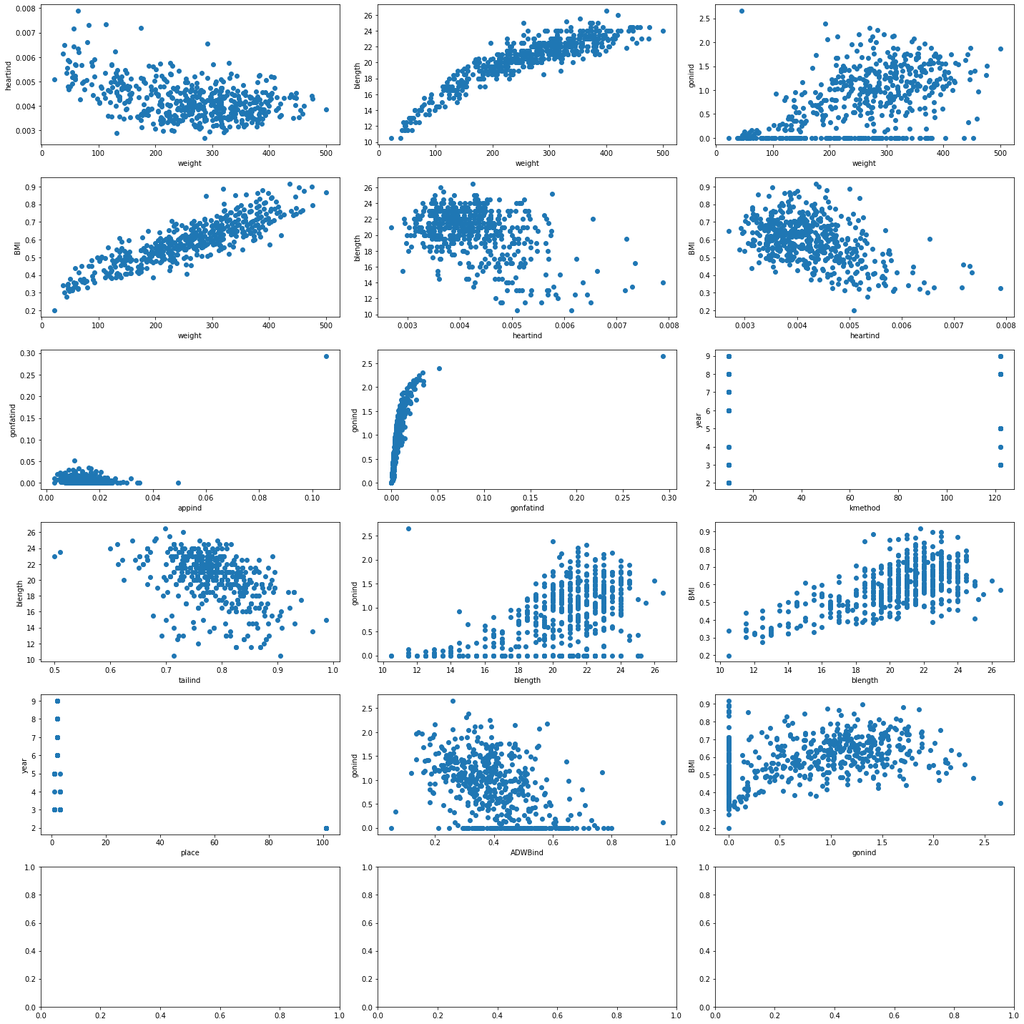

```python
a = (len(pairs) // 3 + 1)
fig, axs = plt.subplots(a, 3, figsize=(20, 20))

for i in range(len(pairs)):
    r = i//3
    c = i%3
    xdata = dataE[pairs[i][0]]
    ydata = dataE[pairs[i][1]]
    axs[r,c].scatter(xdata, ydata)
    axs[r,c].set_xlabel(pairs[i][0])
    axs[r,c].set_ylabel(pairs[i][1])

fig.tight_layout()
```

So some of the strong correlations show a linear trend more clearly and some don't. The clearest linear trend is between BMI and weight.